# Variable Selection Methods

## All Possible Regression

For K potential features there are $2^k$ distinct possible regression models to be tested.

```r
library(olsrr)
model = lm(mpg ~ disp + hp + wt + qsec, data =mtcars)
k = ols_step_all_possible(model)
k
```

|  | Index | N | Predictors | R-Square | Adj. R-Square | Mallow's Cp |
| --- | --- | --- | --- | --- | --- | --- |
| 3 | 1 | 1 | wt | 0.7528328 | 0.7445939 | 12.480939 |
| 1 | 2 | 1 | disp | 0.7183433 | 0.7089548 | 18.129607 |
| 2 | 3 | 1 | hp | 0.6024373 | 0.5891853 | 37.112642 |
| 4 | 4 | 1 | qsec | 0.1752963 | 0.1478062 | 107.069616 |
| 8 | 5 | 2 | hp wt | 0.8267855 | 0.8148396 | 2.369005 |
| 10 | 6 | 2 | wt qsec | 0.8264161 | 0.8144448 | 2.429492 |
| 6 | 7 | 2 | disp wt | 0.7809306 | 0.7658223 | 9.879096 |
| 5 | 8 | 2 | disp hp | 0.7482402 | 0.7308774 | 15.233115 |
| 7 | 9 | 2 | disp qsec | 0.7215598 | 0.7023571 | 19.602810 |
| 9 | 10 | 2 | hp qsec | 0.6368769 | 0.6118339 | 33.472150 |

[output cut: 5 more lines]

`plot` can be used to show the panel of fit criteria for all possible regressions.

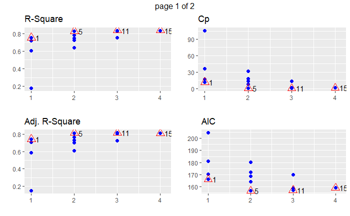

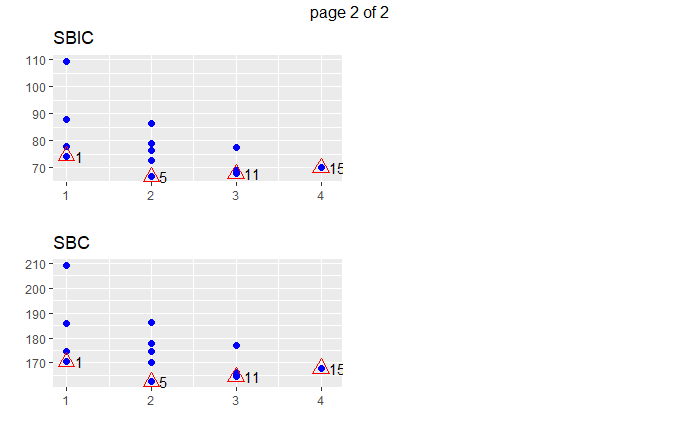

```r
plot(k)
```

## Best Subset Regression

Selects the best subset that perform the best at some objective criteria, such as $R^2$, MS2, AIC, etc.

```r
model = lm(mpg ~ disp + hp + wt + qsec, data = mtcars)
k = ols_step_best_subset(model)
k
```

```
   Best Subsets Regression
------------------------------
Model Index    Predictors
------------------------------
     1         wt
     2         hp wt
     3         hp wt qsec
     4         disp hp wt qsec
------------------------------

                                                   Subsets Regression Summary
---------------------------------------------------------------------------------------------------------------------------------
                       Adj.        Pred
Model    R-Square    R-Square    R-Square     C(p)        AIC        SBIC        SBC         MSEP       FPE       HSP       APC
---------------------------------------------------------------------------------------------------------------------------------
  1        0.7528      0.7446      0.7087    12.4809    166.0294    74.2916    170.4266    296.9167    9.8572    0.3199    0.2801
  2        0.8268      0.8148      0.7811     2.3690    156.6523    66.5755    162.5153    215.5104    7.3563    0.2402    0.2091
  3        0.8348      0.8171       0.782     3.0617    157.1426    67.7238    164.4713    213.1929    7.4756    0.2461    0.2124
  4        0.8351      0.8107       0.771     5.0000    159.0696    70.0408    167.8640    220.8882    7.9497    0.2644    0.2259
---------------------------------------------------------------------------------------------------------------------------------
AIC: Akaike Information Criteria
 SBIC: Sawa's Bayesian Information Criteria
 SBC: Schwarz Bayesian Criteria
 MSEP: Estimated error of prediction, assuming multivariate normality
 FPE: Final Prediction Error
 HSP: Hocking's Sp
 APC: Amemiya Prediction Criteria
```

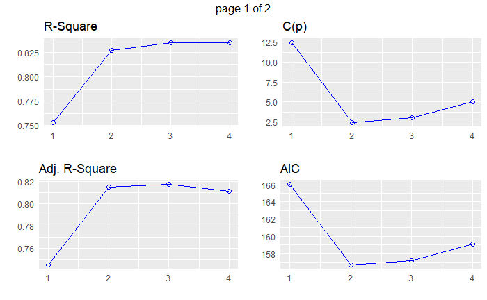

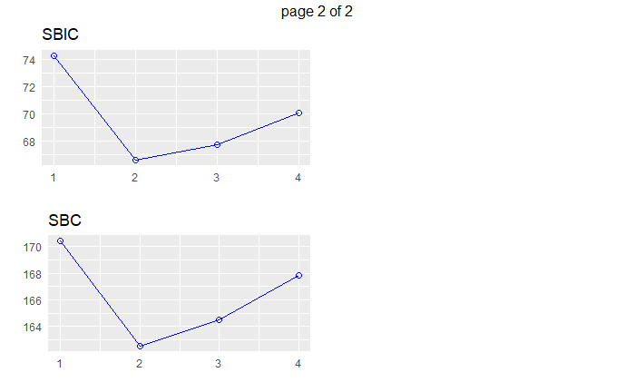

```r
plot(k)
```

## Stepwise Forward Regression

Buils a regression model from a set of features by entering them one by one based on p values. Further details can be obtained by setting `details = true`.

```r
model = lm(y ~ ., data = surgical)
k = ols_step_forward_p(model)
k
```

```
                              Selection Summary
------------------------------------------------------------------------------
        Variable                     Adj.
Step      Entered      R-Square    R-Square     C(p)        AIC         RMSE
------------------------------------------------------------------------------
   1    liver_test       0.4545      0.4440    62.5119    771.8753    296.2992
   2    alc_heavy        0.5667      0.5498    41.3681    761.4394    266.6484
   3    enzyme_test      0.6590      0.6385    24.3379    750.5089    238.9145
   4    pindex           0.7501      0.7297     7.5373    735.7146    206.5835
   5    bcs              0.7809      0.7581     3.1925    730.6204    195.4544
------------------------------------------------------------------------------
```

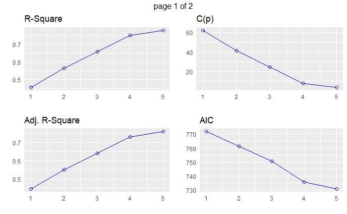

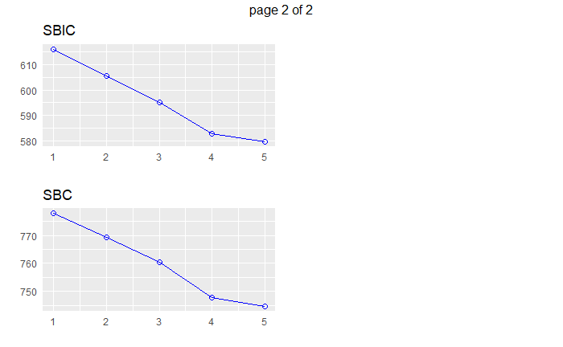

```r
plot(k)
```

## Stepwise Backward Regression

Builds a regression model starting with all features and removing them one by one based on p values. Further details can be obtained by setting `details = true`.

```r
model = lm(y ~ ., data = surgical)
k = ols_step_backward_p(model)
k
```

```
                           Elimination Summary
--------------------------------------------------------------------------
        Variable                  Adj.
Step    Removed     R-Square    R-Square     C(p)       AIC         RMSE
--------------------------------------------------------------------------
   1    alc_mod       0.7818      0.7486    7.0141    734.4068    199.2637
   2    gender        0.7814      0.7535    5.0870    732.4942    197.2921
   3    age           0.7809      0.7581    3.1925    730.6204    195.4544
--------------------------------------------------------------------------
```

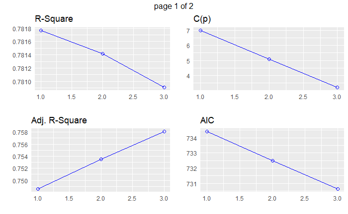

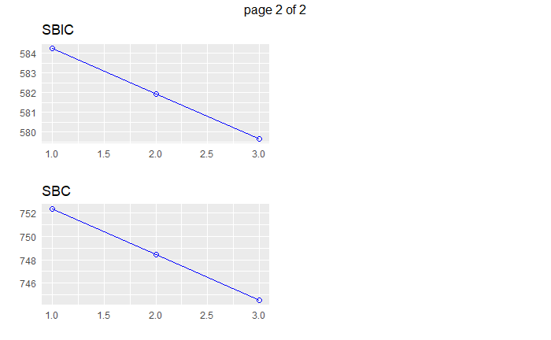

```r
plot(k)
```

## Stepwise regression

An iterative method in which features are entered and removed one by one and decided upon by performing f or t tests to know if they were significant.

```r
model = lm(y ~ ., data = surgical)
k = ols_step_both_p(model)
k
plot(k)
```

[output not shown]

## Stepwise AIC Forward Regression

An iterative method in which features are added one by one and decided upon by checking the Akaike Information Criterion (less is better).

```r
model = lm(y ~ ., data =surgical)
k = ols_step_forward_aic(model)
k
```

```
                             Selection Summary
----------------------------------------------------------------------------
Variable         AIC        Sum Sq           RSS         R-Sq      Adj. R-Sq
----------------------------------------------------------------------------
liver_test     771.875    3804272.477    4565248.060    0.45454      0.44405
alc_heavy      761.439    4743349.776    3626170.761    0.56674      0.54975
enzyme_test    750.509    5515514.136    2854006.401    0.65900      0.63854
pindex         735.715    6278360.060    2091160.477    0.75015      0.72975
bcs            730.620    6535804.090    1833716.447    0.78091      0.75808
----------------------------------------------------------------------------
```

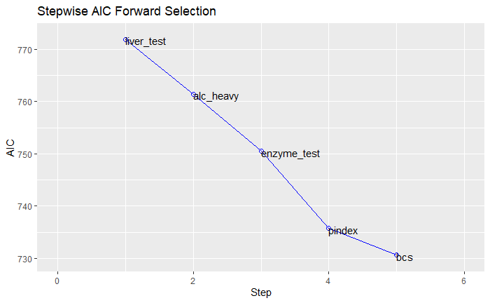

```r
plot(k)
```

## Stepwise AIC Backward Regression

An iterative method in which features are removed one by one and decided upon by checking the Akaike Information Criterion (less is better).

```r
model = lm(y ~ ., data =surgical)
k = ols_step_backward_aic(model)
k
```

```
                        Backward Elimination Summary
---------------------------------------------------------------------------
Variable        AIC          RSS          Sum Sq        R-Sq      Adj. R-Sq
---------------------------------------------------------------------------
Full Model    736.390    1825905.713    6543614.824    0.78184      0.74305
alc_mod       734.407    1826477.828    6543042.709    0.78177      0.74856
gender        732.494    1829435.617    6540084.920    0.78142      0.75351
age           730.620    1833716.447    6535804.090    0.78091      0.75808
---------------------------------------------------------------------------
```

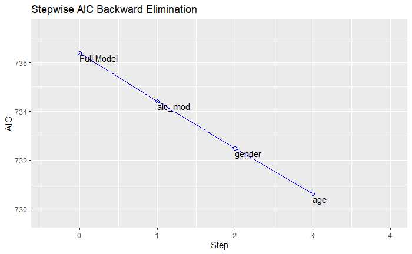

```r
plot(k)
```

## Stepwise AIC Regression

An iterative method in which features are added and removed one by one, and decided upon by checking the Akaike Information Criterion (less is better).

```r
model = lm(y ~ ., data = surgical)
k = ols_step_both_aic(model)
k
```

```
                                     Stepwise Summary
----------------------------------------------------------------------------------------
Variable        Method       AIC          RSS          Sum Sq        R-Sq      Adj. R-Sq
----------------------------------------------------------------------------------------
liver_test     addition    771.875    4565248.060    3804272.477    0.45454      0.44405
alc_heavy      addition    761.439    3626170.761    4743349.776    0.56674      0.54975
enzyme_test    addition    750.509    2854006.401    5515514.136    0.65900      0.63854
pindex         addition    735.715    2091160.477    6278360.060    0.75015      0.72975
bcs            addition    730.620    1833716.447    6535804.090    0.78091      0.75808
----------------------------------------------------------------------------------------
```

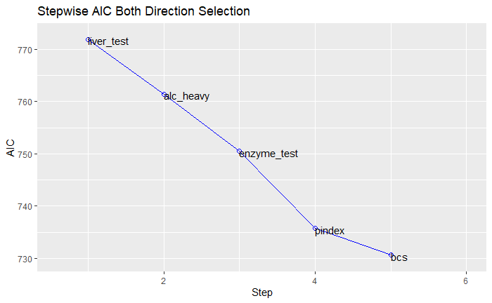

```r
plot(k)
```

## Reference

https://olsrr.rsquaredacademy.com/articles/variable_selection.html